# Introduction to Machine Learning

Derek Sollberger

2020-05-01

# Goals for today

- introduce machine learning (ideas and terminology)
- introduce `tidymodels` package
- practice with a `TidyTuesday` data set

```r
library("tidymodels")
library("tidyverse")
```

# Data: Tour de France

Source: [TidyTuesday](https://github.com/rfordatascience/tidytuesday/blob/master/data/2020/2020-04-07/readme.md) data set from April 7, 2020

```r
tdf_winners <- readr::read_csv('https://raw.githubusercontent.com/rfordatascience/tidytuesday/master/data/2020/2020-04-07/tdf_winners.csv')
```

```r
str(tdf_winners)
```

```
## Classes 'spec_tbl_df', 'tbl_df', 'tbl' and 'data.frame': 106 obs. of  19 variables:
##  $ edition      : num  1 2 3 4 5 6 7 8 9 10 ...
##  $ start_date   : Date, format: "1903-07-01" "1904-07-02" ...
##  $ winner_name  : chr  "Maurice Garin" "Henri Cornet" "Louis Trousselier" "René Pottier" ...
##  $ winner_team  : chr  "La Française" "Conte" "Peugeot–Wolber" "Peugeot–Wolber" ...
##  $ distance     : num  2428 2428 2994 4637 4488 ...
##  $ time_overall : num  94.6 96.1 NA NA NA ...
##  $ time_margin  : num  2.99 2.27 NA NA NA ...
##  $ stage_wins   : num  3 1 5 5 2 5 6 4 2 3 ...
##  $ stages_led   : num  6 3 10 12 5 13 13 3 13 13 ...
##  $ height       : num  1.62 NA NA NA NA NA 1.78 NA NA NA ...
##  $ weight       : num  60 NA NA NA NA NA 88 NA NA NA ...
##  $ age          : num  32 19 24 27 24 25 22 22 26 23 ...
##  $ born         : Date, format: "1871-03-03" "1884-08-04" ...
##  $ died         : Date, format: "1957-02-19" "1941-03-18" ...
##  $ full_name    : chr  NA NA NA NA ...
##  $ nickname     : chr  "The Little Chimney-sweep" "Le rigolo (The joker)" "Levaloy / Trou-trou" NA ...
##  $ birth_town   : chr  "Arvier" "Desvres" "Paris" "Moret-sur-Loing" ...
##  $ birth_country: chr  "Italy" "France" "France" "France" ...
##  $ nationality  : chr  " France" " France" " France" " France" ...
##  - attr(*, "spec")=
##   .. cols(
##   ..   edition = col_double(),
##   ..   start_date = col_date(format = ""),
##   ..   winner_name = col_character(),
##   ..   winner_team = col_character(),
##   ..   distance = col_double(),
##   ..   time_overall = col_double(),
##   ..   time_margin = col_double(),
##   ..   stage_wins = col_double(),
##   ..   stages_led = col_double(),
##   ..   height = col_double(),
##   ..   weight = col_double(),
##   ..   age = col_double(),
##   ..   born = col_date(format = ""),
##   ..   died = col_date(format = ""),
##   ..   full_name = col_character(),
##   ..   nickname = col_character(),
##   ..   birth_town = col_character(),
##   ..   birth_country = col_character(),
##   ..   nationality = col_character()
##   .. )
```

```r
colnames(tdf_winners)
```

```
##  [1] "edition"       "start_date"    "winner_name"   "winner_team"
##  [5] "distance"      "time_overall"  "time_margin"   "stage_wins"
##  [9] "stages_led"    "height"        "weight"        "age"
## [13] "born"          "died"          "full_name"     "nickname"
## [17] "birth_town"    "birth_country" "nationality"
```

# Cleaning Data

```r
df <- tdf_winners %>%
  select(c(distance, time_overall,
           height, weight, age)) %>%
  filter(complete.cases(.)) %>%
  filter(height >= 1.7) %>%
  mutate(pace = distance / time_overall) %>%
  select(c(pace, height, weight, age))
```

```r
dim(df)
```

```
## [1] 62  4
```

# Data Visualization

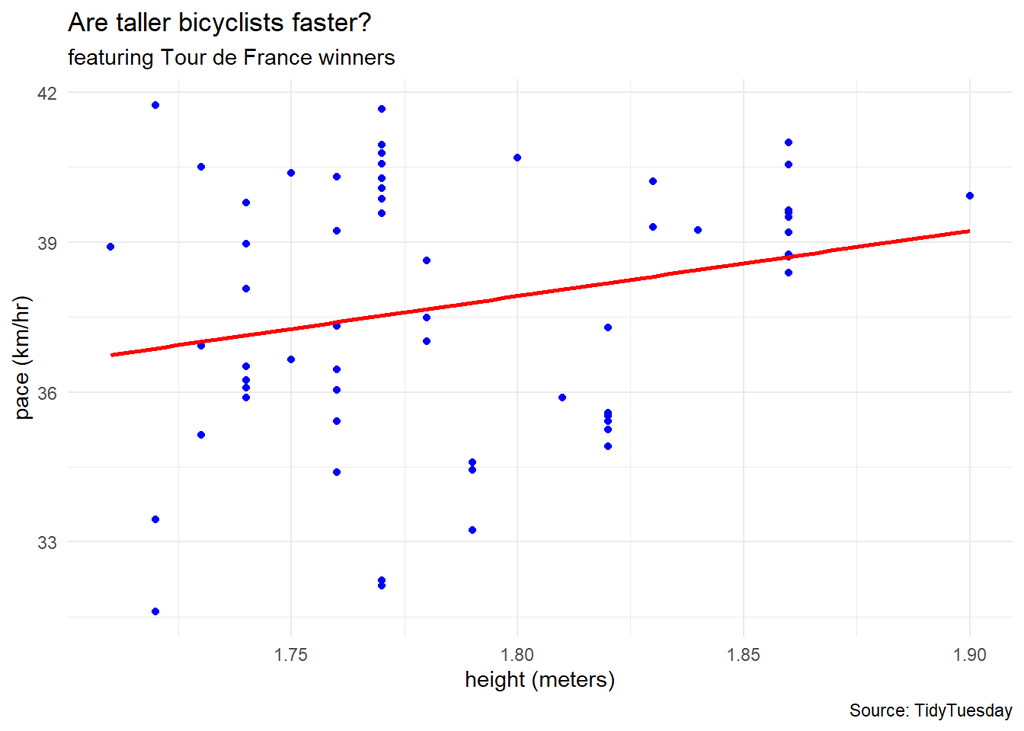

```r
df %>%
  ggplot(aes(x = height, y = pace)) +
  geom_point(color = "blue") +
  geom_smooth(method = "lm", se = FALSE, color = "red") +
  labs(title = "Are taller bicyclists faster?",
       subtitle = "featuring Tour de France winners",
       caption = "Source: TidyTuesday",
       x = "height (meters)",
       y = "pace (km/hr)") +
  theme_minimal()
```

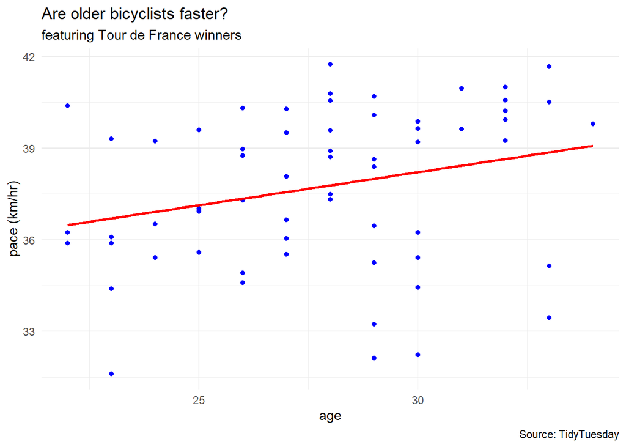

```r
df %>%
  ggplot(aes(x = age, y = pace)) +
  geom_point(color = "blue") +
  geom_smooth(method = "lm", se = FALSE, color = "red") +
  labs(title = "Are older bicyclists faster?",
       subtitle = "featuring Tour de France winners",
       caption = "Source: TidyTuesday",
       x = "age",
       y = "pace (km/hr)") +
  theme_minimal()
```

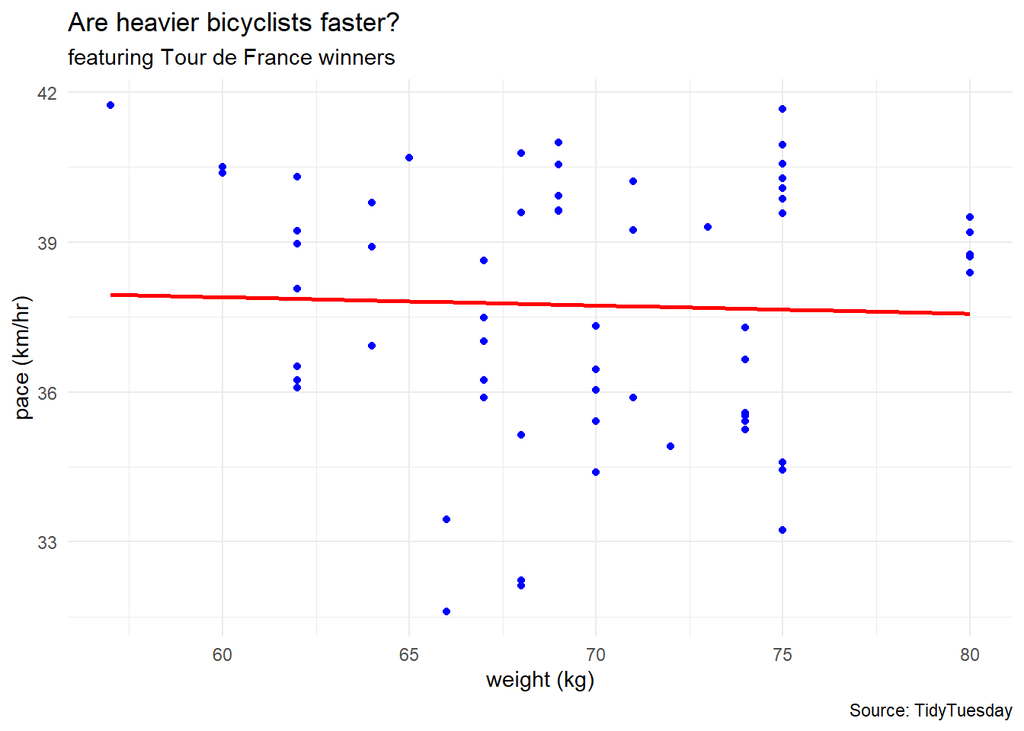

```r
df %>%
  ggplot(aes(x = weight, y = pace)) +
  geom_point(color = "blue") +
  geom_smooth(method = "lm", se = FALSE, color = "red") +
  labs(title = "Are heavier bicyclists faster?",
       subtitle = "featuring Tour de France winners",
       caption = "Source: TidyTuesday",
       x = "weight (kg)",
       y = "pace (km/hr)") +
  theme_minimal()
```

# First Model

“With tidymodels, we start by specifying the functional form of the model that we want using the `parsnip` package.”

```r
linear_reg()
```

```
## Linear Regression Model Specification (regression)
```

## model engine

“However, now that the type of model has been specified, a method for fitting or training the model can be stated using the engine. The engine value is often a mash-up of the software that can be used to fit or train the model as well as the estimation method.”

```r
linear_reg() %>%
  set_engine("lm") #linear model
```

```
## Linear Regression Model Specification (regression)
##
## Computational engine: lm
```

## fitting a model

```r
lm_fit <- linear_reg() %>%
  set_engine("lm") %>%
  fit(pace ~ height + weight + age, data = df)
lm_fit
```

```
## parsnip model object
##
## Fit time:  0ms
##
## Call:
## stats::lm(formula = formula, data = data)
##
## Coefficients:
## (Intercept)       height       weight          age
##      3.8455      21.0987      -0.1387       0.2113
```

## examining a model

```r
tidy(lm_fit)
```

```
## # A tibble: 4 x 5
##   term        estimate std.error statistic p.value
##   <chr>          <dbl>     <dbl>     <dbl>   <dbl>
## 1 (Intercept)    3.85    12.3        0.313  0.755
## 2 height        21.1      8.06       2.62   0.0112
## 3 weight        -0.139    0.0685    -2.03   0.0474
## 4 age            0.211    0.0979     2.16   0.0350
```

## interaction terms

```r
lm_fit_with_interaction <- linear_reg() %>%
  set_engine("lm") %>%
  fit(pace ~ height + weight + age + height:weight + height:age + weight:age +
        height:weight:age,
      data = df)
lm_fit_with_interaction
```

```
## parsnip model object
##
## Fit time:  0ms
##
## Call:
## stats::lm(formula = formula, data = data)
##
## Coefficients:
##       (Intercept)             height             weight                age
##          924.8499          -444.1560           -15.6339           -27.8628
##     height:weight         height:age         weight:age  height:weight:age
##            7.9297            13.9352             0.4802            -0.2425
```

```r
tidy(lm_fit_with_interaction)
```

```
## # A tibble: 8 x 5
##   term              estimate std.error statistic p.value
##   <chr>                <dbl>     <dbl>     <dbl>   <dbl>
## 1 (Intercept)        925.     2272.        0.407   0.686
## 2 height            -444.     1287.       -0.345   0.731
## 3 weight             -15.6      32.8      -0.477   0.635
## 4 age                -27.9      80.3      -0.347   0.730
## 5 height:weight        7.93     18.5       0.428   0.670
## 6 height:age          13.9      45.5       0.306   0.761
## 7 weight:age           0.480     1.16      0.414   0.680
## 8 height:weight:age   -0.243     0.656    -0.370   0.713
```

# Predictions

## new data

- SpongeBob is a 26-year-old, 1.77 m tall bicyclist who weighs 55 kg
- Patrick is a 25-year-old, 1.81 m tall bicyclist who weighs 75 kg
- Squidward is a 31-year-old, 1.89 m tall bicyclist who weighs 65 kg

```r
new_contestants <- data.frame(name = c("SpongeBob", "Patrick", "Squidward"),
                              age = c(26, 25, 31),
                              height = c(1.77, 1.81, 1.89),
                              weight = c(55, 75, 65))

mean_predictions <- predict(lm_fit, new_data = new_contestants)
mean_predictions
```

```
## # A tibble: 3 x 1
##   .pred
##   <dbl>
## 1  39.1
## 2  36.9
## 3  41.3
```

## confidence intervals

```r
CI_predictions <- predict(lm_fit,
                          new_data = new_contestants,
                          type = "conf_int")
CI_predictions
```

```
## # A tibble: 3 x 2
##   .pred_lower .pred_upper
##         <dbl>       <dbl>
## 1        37.1        41.0
## 2        35.9        38.0
## 3        39.0        43.5
```

## error bars

```r
plot_df <- new_contestants %>%
  bind_cols(mean_predictions) %>%
  bind_cols(CI_predictions)
plot_df
```

```
##        name age height weight    .pred .pred_lower .pred_upper
## 1 SpongeBob  26   1.77     55 39.05386    37.07966    41.02807
## 2   Patrick  25   1.81     75 36.91179    35.85758    37.96601
## 3 Squidward  31   1.89     65 41.25491    38.97189    43.53794
```

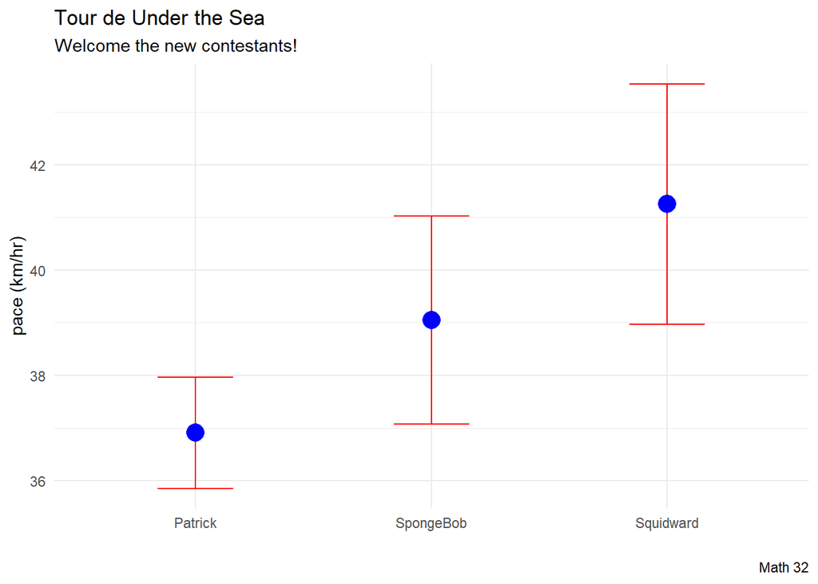

```r
plot_df %>%
  ggplot(aes(x = name)) +
  geom_errorbar(aes(ymin = .pred_lower,
                    ymax = .pred_upper),
                color = "red",
                width = 0.32) +
  geom_point(aes(y = .pred), color = "blue", size = 5) +
  labs(title = "Tour de Under the Sea",
       subtitle = "Welcome the new contestants!",
       caption = "Math 32",
       x = "",
       y = "pace (km/hr)") +
  theme_minimal()
```

# Data Splitting

- “The *training set* is used to estimate parameters, compare models and feature engineering techniques, tune models, etc.”
- “The *test set* is held in reserve until the end of the project, at which point there should only be one or two models under serious consideration. It is used as an unbiased source for measuring final model performance.”

```r
data_split <- initial_split(df)
train_df <- training(data_split)
test_df <- testing(data_split)
```

```r
print(paste("The number of observations in the training set is:", nrow(train_df)))
```

```
## [1] "The number of observations in the training set is: 47"
```

```r
print(paste("The number of observations in the testing set is:", nrow(test_df)))
```

```
## [1] "The number of observations in the testing set is: 15"
```

# visualizing the split

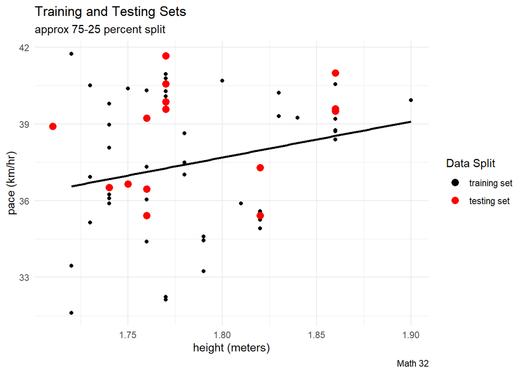

```r
data_split <- initial_split(df)
train_df <- training(data_split)
test_df <- testing(data_split)

train_df %>%
  ggplot(aes(x = height, y = pace)) +
  geom_point(aes(color = "training set"),
             # color = "black"
             ) +
  geom_smooth(method = "lm",
              aes(x = height, y = pace),
              color = "black",
              data = train_df,
               se = FALSE) +
  geom_point(aes(x = height, y = pace, color = "testing set"),
             # color = "red",
             data = test_df,
             size = 3) +
  labs(title = "Training and Testing Sets",
       subtitle = "approx 75-25 percent split",
       caption = "Math 32",
       x = "height (meters)",
       y = "pace (km/hr)") +
  scale_color_manual(name = "Data Split",
                     breaks = c("training set", "testing set"),
                     values = c("training set" = "black",
                                "testing set" = "red")) +
  theme_minimal()
```

Tip: run the last code block several times (keyboard shortcut: CTRL-SHFT-ENTER) for the full effect!